# batplotR - BatScope Datenvisualisation with R

## Über `batplotR`

`batplotR` ist eine R Package die im Rahmen eines Zivildiensteinsatzes bei der [Stiftung Fledermausschutz Schweiz](http://www.fledermausschutz.ch) entwickelt wurde. Sie wurde für die Darstellung von mit [BatScope](http://www.wsl.ch/dienstleistungen/produkte/software/batscope/index_DE) ausgewerteten Bioakustikdaten entwickelt und erlaubt es kurze (d.h. über eine Nacht) und lange (d.h. mehrere Nächte) Beobachtungsreihen darzustellen. Ausgangspunkt ist in jedem Fall ein `.xlsx`-Exportfile von Batscope ( getestet , mit BatScope v.3.1.6)

Die Package ist GPL-3 lizenziert und auf [GitHub gehostet](https://github.com/dcangst/batplotr), kann also beliebig geforkt, weitergegeben und verändert werden.

Die folgenden Befehle sind auch als R Dokument (`batplotr_anleitung.R`) zusammengefasst auf der Dropbox!

## Installation

`batplotR` kann direkt von GitHub installiert werden, Voraussetzung ist die Package [`devtools`](https://github.com/hadley/devtools) die über CRAN erhältlich ist und wie folgt installiert werden kann:

```r
install.packages(c("devtools"),dependencies=TRUE)
```

danach kann batplotR direkt von GitHub installiert werden (es werden auch verschiedene andere Packages installiert, die von batplotR benötigt werden):

```r
devtools::install_github("dcangst/batplotr",dependencies=TRUE)
```

## Benutzung

mit `batplotR` visualisieren Sie ihre BatScope-Projekte in *3 einfachen Schritten!*

1. Daten laden!
2. Daten zusammenfassen!
3. Daten visualizieren!

et voila!

### Laden der Package

Zuerst wird die Package geladen und das Arbeitsverzeichniss[^1] gesetzt.

```r
library(batplotr)
setwd("/Users/daniel/Dropbox/Bioakustik Austausch Manu Daniel")
```

### Laden der BatScope Daten

jetzt können die Daten eingelesen werden. Dafür wird der Befel `readBatscopeXLSX` verwendet.

```r
daten <- readBatscopeXLSX(
  species_col_name = "AutoClass1",
  quality_col_name = "AutoClass1Qual",
  quality_threshold  = 0.8
  )
```

```
##
## /Users/Daniel/Dropbox/Bioakustik Austausch Manu Daniel/Export_2015-04-14_11.50.35_PT.xlsx
## wird eingelesen, kann eine Weile dauern...
```

```
## Summary of AutoClass1Qual
##
##    Min. 1st Qu.  Median    Mean 3rd Qu.    Max.    NA's
##   0.306   0.591   0.686   0.696   0.798   1.000    9552
##
## 'Discarded 27350 of 33199 sequences (82.382%); 5849 remaining
```

Der Befehl ruft ein ‘Datei öffnen…’ Dialog auf bei dem das `.xlsx`-file vom BatScope export ausgewählt werden muss. Ausserdem werden noch die folgenden Parameter benötigt:

Tabelle 1: Parameter der Funktion `readBatscopeXLSX`

| Parameter | Was? | Standardwert |
| --- | --- | --- |
| path | Pfad zum `.xlsx` -file | file.choose()[^2] |
| species_col_name | Spaltenname Spezies | `"AutoClass1"` |
| quality_col_name | Spaltenname Qualität | `"AutoClass1Qual"` |
| quality_threshold | minimale Qualität der Spezieszuordnung | `0.8` |

(*Mit R 3.1.3 wird ein Fehler in der Konsole ausgeworfen. Dieser kann ignoriert werden*)

Die eingelesenen Daten werden unter dem Namen `daten` abgelegt (mit Hilfe der Zuweisung `<-`). Wie der Tabelle zu entnehmen ist, hätten in diesem Fall die Daten auch mit `readBatscopeXLSX()` alleine eingelesen werden können, da alle Standardwerte verwendet wurden.

Es empfiehlt sich den Import mit der Funktion `str(daten)` oder `head(daten)`anzuschauen. Als nächstes werden die Daten nach Standorten und Tagen in kurze Zeitabschnitte zusammengefasst (sogenanntes ‘binning’).

### Zusammenfassung der Daten

Um die Daten zu visualisieren werden die einzelnen Sequenzen in kurzen Zeitabschnitten zusammengefasst. Die Länge dieser Zeitabschnitte kann vom Benutzer eingestellt werden. Ausserdem werden hier die Zeiten des Sonnenauf und -untergangs berechnet (nach Algorithmen der NOAA). Bei grossen Datensätzen kann dieser Befehl eine kleine Weile dauern.

Für die Zusammenfassung wird der Befehl `sumBatscopeData` ausgeführt:

```r
  daten_sum <- sumBatscopeData(
    daten,
    bin_length=5,
    progress="text"
    )
```

```
## Zusammenfassung nach Tag, Project, Spezies und Bins...
## Zusammenfassung Total aller species...
## GPS Koordinaten bearbeiten...
```

```
## Koordinaten von Batlogger verwendet.
```

```
##         ProjectName      lat     long
## 1 PT 2014 Limmattal 47.38614 8.517271
## 2       PT 2014 See 47.38596 8.517406
## 3 PT 2014 Uetliberg 47.38582 8.517228
## 4  PT 2014 Waidberg 47.38631 8.517434
## Berechne Sonnenauf und -untergangszeiten...
```

Der Befehl benötigt die folgenden Parameter:

Tabelle 2: Parameter der Funktion `sumBatscopeData`

[output not shown]

Die eingelesenen Daten werden unter dem Namen `daten_sum` als data.frame abgelegt (mithilfe der Zuweisung `<-`). Wie der Tabelle zu entnehmen ist, hätten in diesem Fall die Daten auch mit `sumBatscopeData(daten)` alleine eingelesen werden können, da alle Standardwerte verwendet wurden. Mit `str(daten_sum)` erhält man einen kurzen Überblick über die Daten

```r
str(daten_sum)
```

```
## 'data.frame':    4329 obs. of  13 variables:
##  $ ProjectName: Factor w/ 4 levels "PT 2014 Limmattal",..: 1 1 1 1 1 1 1 1 1 1 ...
##  $ SurveyDate : POSIXct, format: "2014-03-07" "2014-03-07" ...
##  $ species    : Factor w/ 23 levels "all","Eptesicus nilssonii",..: 2 13 15 15 15 15 15 15 14 14 ...
##  $ bins_factor: Factor w/ 16896 levels "2014-03-07 13:00:00",..: 76 100 72 73 77 112 113 132 11766 11801 ...
##  $ n_events   : int  1 1 3 3 1 1 1 1 1 1 ...
##  $ sum_nCalls : num  1 1 161 113 54 1 1 1 5 16 ...
##  $ meanT_BL   : num  9 6 12 12 9 5 4 3 15 14 ...
##  $ bins       : POSIXct, format: "2014-03-07 19:15:00" "2014-03-07 21:15:00" ...
##  $ lat        : num  47.4 47.4 47.4 47.4 47.4 ...
##  $ long       : num  8.52 8.52 8.52 8.52 8.52 ...
##  $ sunset     : POSIXct, format: "2014-03-07 18:19:32" "2014-03-07 18:19:32" ...
##  $ sunrise    : POSIXct, format: "2014-03-08 06:53:13" "2014-03-08 06:53:13" ...
##  $ bin_length : num  5 5 5 5 5 5 5 5 5 5 ...
```

Mit den Daten kann natürlich mit den vielen Tools von R weitergearbeitet werden. Im folgenden ein Beispiel das die Package [`plyr`](http://plyr.had.co.nz) benützt um die Summe von Events (d.h. Anzahl Sequenzen) an den verschiedenen Standorten pro Tag auszurechnen (aus Platzgründen werden hier nur die ersten 6 Zeilen angezeigt)

```r
  ddply(daten_sum,.(ProjectName,SurveyDate),summarize,n_events_day=sum(n_events))
```

```
##         ProjectName SurveyDate n_events_day
## 1 PT 2014 Limmattal 2014-03-07           24
## 2 PT 2014 Limmattal 2014-03-11           28
## 3 PT 2014 Limmattal 2014-03-17           18
## 4 PT 2014 Limmattal 2014-03-20           46
## 5 PT 2014 Limmattal 2014-03-28          144
## 6 PT 2014 Limmattal 2014-04-17           24
```

### Plotten der Daten

Das Objekt `daten_sum`, generiert mit `sumBatscopeData`, kann jetzt auch mit den beiden Plotfunktionen `nightPlot` und `periodPlot` verwendet werden.

#### nightPlot

Die Funktion `nightPlot` generiert ein [ggplot](http://ggplot2.org) Objekt und hat folgende Parameter:

Tabelle 3: Parameter der Funktion `nightPlot`

[output not shown]

Die Standardwerte generieren in der Regel einen guten ersten Eindruck der Daten:

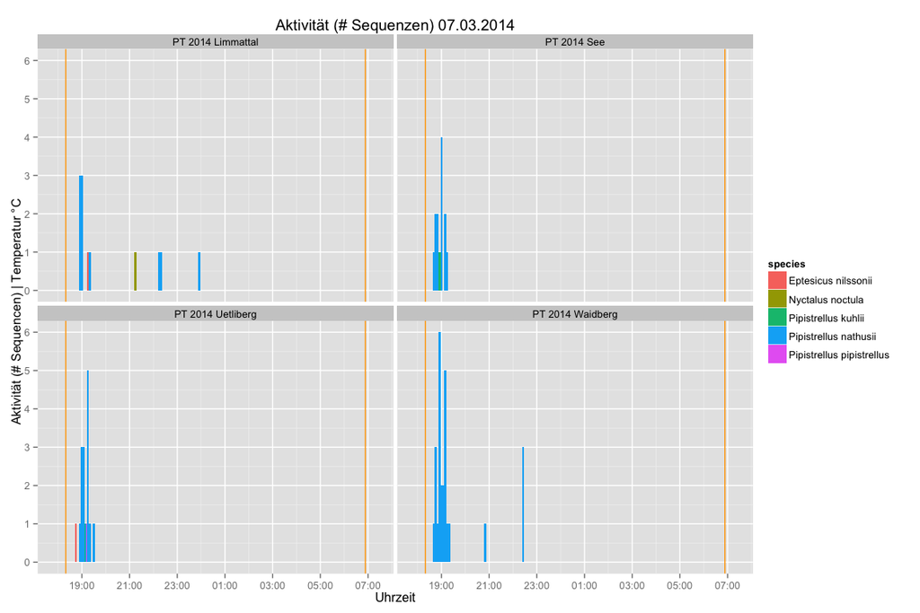

Figure 1: Beispiel eines `nightPlots`

```r
nightPlot(daten_sum)
```

Im folgenden einige Beispiele für die verschiedenen Optionen:

- **Datumsauswahl**

  mit dem R-Befehl `unique` können zunächst mal die Daten angezeigt werden, die im Datensatz vorhanden sind. Danach kann eines der Daten als Argument an `nightPlot` übergeben werden:

  ```r
  unique(daten_sum$SurveyDate)
  nightPlot(daten_sum,day="2014-07-24")
  ```

  da `unique(daten_sum$Survey)` ein Vector zurückgibt kann ein Element davon auch gleich an `nightPlot` übergeben werden:

  ```r
  nightPlot(daten_sum,day=unique(daten_sum$SurveyDate)[24])
  ```

  es können auch mehrere Tage angegeben werden (sollten aufeinanderfolgend sein):

  ```r
  nightPlot(daten_sum,day=c("2014-08-23","2014-08-24"))
  ```

- **Auswahl einer/mehrerer Spezies**

  ähnlich wie die Daten können auch die Spezies ausgewählt werden.

  ```r
  nightPlot(daten_sum,"2014-07-24",sel_species="Pipistrellus nathusii")
  nightPlot(daten_sum,"2014-07-24",sel_species=unique(daten_sum$species)[3])
  ```

  Es können auch mehrere Spezies ausgewählt werden:

  ```r
  nightPlot(daten_sum,day="2014-07-24",sel_species=c("Pipistrellus nathusii","Pipistrellus kuhlii"))
  nightPlot(daten_sum,day="2014-07-24",sel_species=unique(daten_sum$species)[3:4])
  ```

- **Darstellung von nur einem Standort**

  Um nur einen der Standorte im Datensatz anzuzeigen müssen zuerst die Daten eingschränkt werden:

  ```r
  unique(daten_sum$ProjectName)
  daten_sum_StO1 <- subset(daten_sum,ProjectName=="PT 2014 Waidberg")
  # oder direkt:
  daten_sum_StO1 <- subset(daten_sum,ProjectName==unique(daten_sum$ProjectName)[4])
  nightPlot(daten_sum_StO1, day="2014-07-24")
  ```

- **x_limits & y_limits**

  um die Achsen anzupassen werden die Werte `x_limits` & `y_limits` gesetzt:

  ```r
  nightPlot(daten_sum_StO1, day=c("2014-08-23","2014-08-24"), x_limits=as.POSIXct(c("2014-08-23 16:00","2014-08-25 10:00")), y_limits=c(0,12))
  ```

Ein Beispiel mit vielen Optionen:

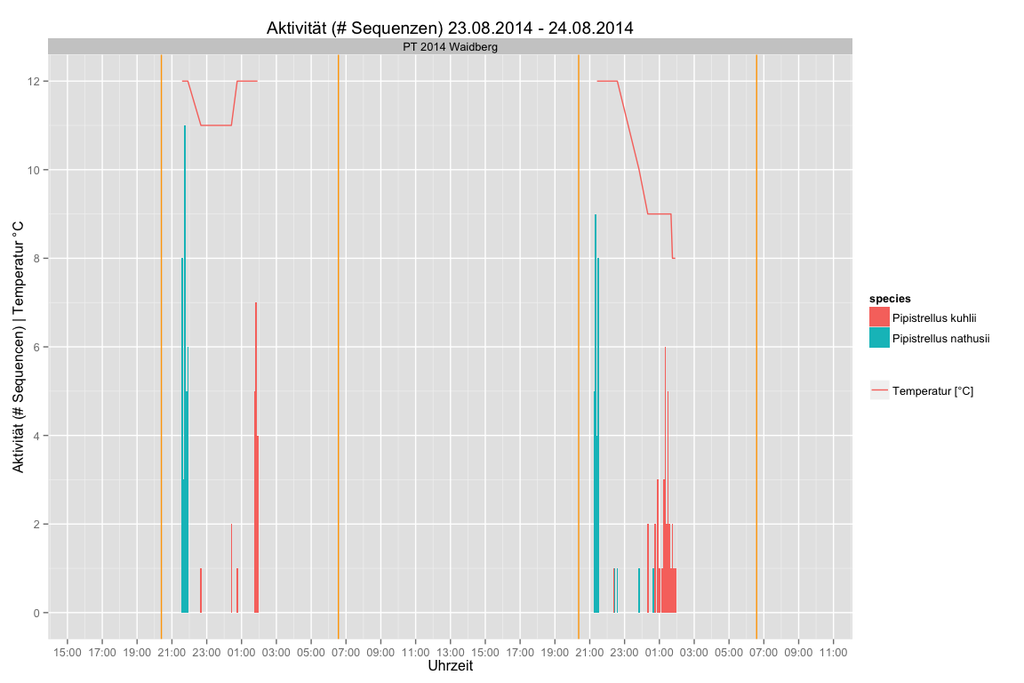

Figure 2: Beispiel eines `nightPlots` mit vielen Optionen

```r
    daten_sum_StO1 <- subset(daten_sum,ProjectName==unique(daten_sum$ProjectName)[4])
    nightPlot(daten_sum_StO1, day=c("2014-08-23","2014-08-24"),sel_species=unique(daten_sum_StO1$species)[c(1,2,4)], x_limits=as.POSIXct(c("2014-08-23 16:00","2014-08-25 10:00")), y_limits=c(0,12),plot_T=TRUE)
```

#### periodPlot

Die Funktion `periodPlot` generiert ein [ggplot](http://ggplot2.org) Objekt und hat folgende Parameter und funktioniert im wesentlichen ähnlich wie `nightPlot`

Tabelle 4: Parameter der Funktion `periodPlot`

| Parameter | Was? | Standardwerte |
| --- | --- | --- |
| plotData | `data.frame` generiert mit `sumBatscopeData’ | - |
| start_date | Beginn der Zeitperiode | Anfang des Jahres des ersten Datensatzes |
| end_date | Beginn der Zeitperiode | Ende des Jahres des letzten Datensatzes |
| sel_species | Name der Spezies oder Namen von mehreren Spezies als Vektor oder `"every"` für alle Spezies einzeln oder `"all"` für die Summe aller Spezies | `"every"` |
| x_limits | höchster und tiefster Wert der x-Achse (ein Vektor im POSIXct Format), `NULL` für automatisch (= start_date - end_date) | `NULL` |
| y_limits | höchster und tiefster Wert der y-Achse (ein Charakter oder POSIXct Vektor) mit Datum 1900-01-01 (abends) oder 1900-01-02 (morgens). `NULL` für automatisch. | `NULL` |

Beispiel mit Standardwerten:

```
## Plotting number of sequences over period:
## [1] 2014-01-01 CET--2015-01-01 CET
```

```
## Warning: Removed 363 rows containing missing values (geom_point).
```

```
## Warning: Removed 362 rows containing missing values (geom_point).
```

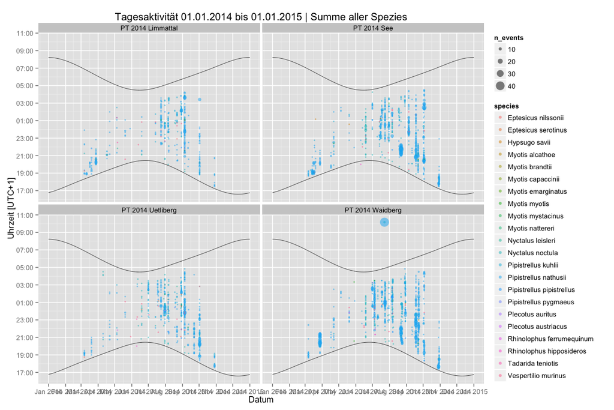

Figure 3: Beispiel eines `periodPlots`

```r
periodPlot(daten_sum)
```

Die generierten Warnmeldungen hängen damit zusammen, das nicht für alle Tage alle Daten vorhanden sind.

```r
plot1 <- periodPlot(daten_sum,start_date="2014-03-01",end_date="2014-11-01",sel_species=unique(daten_sum$species)[3:5],y_limits=c("1900-01-01 17:30","1900-01-02 08:30"))
```

```
## Plotting number of sequences over period:
## [1] 2014-03-01 CET--2014-11-01 CET
```

Die effektiv dargestellten Daten können dann dem generierten `ggplot` Objekt entnommen werden:

```r
head(plot1$data)
```

```
##         ProjectName SurveyDate      lat     long              sunset
## 1 PT 2014 Limmattal 2014-03-01 47.38614 8.517271 2014-03-01 18:10:39
## 2 PT 2014 Limmattal 2014-03-02 47.38614 8.517271 2014-03-02 18:12:09
## 3 PT 2014 Limmattal 2014-03-03 47.38614 8.517271 2014-03-03 18:13:38
## 4 PT 2014 Limmattal 2014-03-04 47.38614 8.517271 2014-03-04 18:15:07
## 5 PT 2014 Limmattal 2014-03-05 47.38614 8.517271 2014-03-05 18:16:36
## 6 PT 2014 Limmattal 2014-03-06 47.38614 8.517271 2014-03-06 18:18:04
##               sunrise species bins_factor n_events sum_nCalls meanT_BL
## 1 2014-03-02 07:04:46    <NA>        <NA>       NA         NA       NA
## 2 2014-03-03 07:02:52    <NA>        <NA>       NA         NA       NA
## 3 2014-03-04 07:00:58    <NA>        <NA>       NA         NA       NA
## 4 2014-03-05 06:59:03    <NA>        <NA>       NA         NA       NA
## 5 2014-03-06 06:57:07    <NA>        <NA>       NA         NA       NA
## 6 2014-03-07 06:55:10    <NA>        <NA>       NA         NA       NA
##   bins bin_length time        sunrise_time         sunset_time
## 1 <NA>         NA <NA> 1900-01-02 07:04:47 1900-01-01 18:10:40
## 2 <NA>         NA <NA> 1900-01-02 07:02:53 1900-01-01 18:12:10
## 3 <NA>         NA <NA> 1900-01-02 07:00:59 1900-01-01 18:13:39
## 4 <NA>         NA <NA> 1900-01-02 06:59:04 1900-01-01 18:15:08
## 5 <NA>         NA <NA> 1900-01-02 06:57:08 1900-01-01 18:16:37
## 6 <NA>         NA <NA> 1900-01-02 06:55:11 1900-01-01 18:18:05
```

## Weitere Scripts

### `batplotr_anleitung.R`

enthält die hier besprochenen Befehle in einer einfachen .R Datei .

### `Auswertung_PrimeTower.R`

ein Beispiel für die Benutzung der Package (im Prinzip ähnlich wie `batplotr_anleitung.R`)

### `Analyse_BatLoggerLogfiles.R`

Script für die Analyse von vielen BatLogger Log-Files. Für Fortgeschrittene. Und dauert lange. Es empfiehlt sich die Daten bereits beim Import in BatScope zu sortieren

## Hilfe

Die Package sowie alle Funktionen haben eine Hilfeseite die mit dem R-Befehl `?` abgerufen werden kann, e.g.:

```r
?batplotr
?nightlot
```

## Entwicklung

Die Package wurde in R 3.1.2 getestet und der Quellcode ist auf [github](https://github.com/dcangst/batplotr) hinterlegt. Die Package kann also frei weiterentwickelt werden!

[^1]: Das Arbeitsverzeichniss in `R` ist das Standardverzeichnis relativ zu dem R alle angegebenen Pfad- und Dateinamen interpretiert. Hier werden z.B. Dateien gespeichert, wenn man nicht einen kompletten Pfad angibt.
[^2]: zeigt einen ‘Datei öffnen…’-Dialog an